# Making age structure data by province

2023-02-24

## Introduction

The code below uses raster-based modelled data from WorldPop on age structure to generate a data frame of age structure by administrative divisions (here provinces). The GitHub repository of this code is https://github.com/OUCRU-Modelling/aes. To transform this code into an R script, use:

```r
knitr::purl("age_structure.Rmd", "age_structure.R")
```

## Local folders

Specifying the input and output folders:

```r
root <- "~/OneDrive - Oxford University Clinical Research Unit/data/"
gadm_data_folder <- paste0(root, "GADM/")
wpop_data_folder <- paste0(root, "WorldPop/raw/age structure/Vietnam")
wpop_data_processed <- paste0(root, "WorldPop/processed/age structure/Vietnam/age_data.rds")
```

Checking whether the WorldPop processed data already exist locally:

```r
data_available <- file.exists(wpop_data_processed)
```

## Packages

Packages needed for the analysis:

```r
needed_package <- c("dplyr", "tidyr", "purrr", "terra", "stringr", "sf", "parallel", "magrittr")
```

Installing the packages that are not already installed:

```r
to_install <- needed_package[which(!needed_package %in% installed.packages()[, "Package"])]
if (length(to_install)) install.packages(to_install)
```

Loading the packages:

```r
dev_null <- sapply(needed_package, function(libname) library(libname, character.only = TRUE))
rm(dev_null)
```

## Downloading provinces polygons data from GADM

GADM root URL:

```r
gadm <- "https://geodata.ucdavis.edu/gadm/"
```

Version and format:

```r
vers_form <- "gadm3.6/Rsf/"
```

File:

```r
file_name <- "gadm36_VNM_1_sf.rds"
```

Creating the local folder structure if it does not exist:

```r
local_folder <- paste0(gadm_data_folder, vers_form)
if (!dir.exists(local_folder)) dir.create(local_folder, recursive = TRUE)
```

Downloading the data if not already available locally:

```r
local_file <- paste0(local_folder, file_name)
if (!file.exists(local_file)) download.file(paste0(gadm, vers_form, file_name), local_file)
```

Loading the polygons data:

```r
provinces <- local_file %>%
  readRDS() %>%
  st_set_crs(4326) # setting the modern code of the WGS 84 projection
```

```
## old-style crs object detected; please recreate object with a recent sf::st_crs()
```

Checking the map of the provinces polygons:

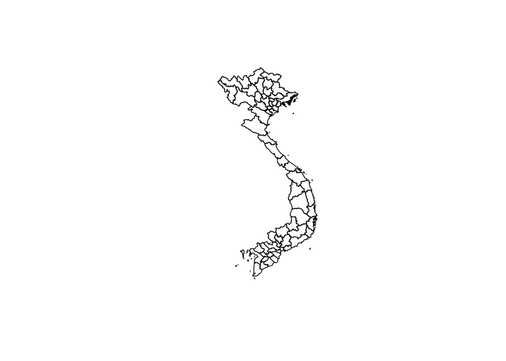

```r
provinces %>%
  st_geometry() %>%
  plot()
```

## Downloading demographic raster data from WorldPop

WorldPop URL:

```r
worldpop <- "https://data.worldpop.org/"
```

All the combinations of years, ages and gender:

```r
ages <- c(0, 1, seq(5, 80, 5))

combinations <- expand_grid(years = 2000:2020,
                            ages  = ages,
                            sexes = c("f", "m"))
```

Creating the long files names:

```r
files_names <- with(combinations,
                    paste0("GIS/AgeSex_structures/Global_2000_2020/",
                           years, "/VNM/vnm_", sexes, "_", ages, "_", years, ".tif"))
```

The corresponding local files names:

```r
local_files_names <- paste0(wpop_data_folder, str_remove(files_names, "^GIS.*VNM"))
```

Checking for those that do not exist locally yet:

```r
sel <- which(!map_lgl(local_files_names, file.exists))
```

Downloading the files that are missing:

```r
if (length(sel) & !data_available) {
  walk2(paste0(worldpop, files_names[sel]), local_files_names[sel], download.file)
}
```

## Generating province data

A function that converts the polygon of a given province of `provinces` into a `SpatVector` object:

```r
prov2vect <- function(prov_name) {
  provinces %>%
    filter(VARNAME_1 == prov_name) %>%
    vect()
}
```

A function that crops and masks a `SpatRaster` object `rst` with a `SpatVector` object `pol`:

```r
crop_mask <- function(rst, pol) {
  rst %>%
    crop(pol) %>%
    mask(pol)
}
```

A function that extracts the number of people of a raster `rst` inside a polygon `pol`:

```r
nb_people <- function(rst, pol) {
  crop_mask(rst, pol) %>%
    values() %>%
    sum(na.rm = TRUE)
}
```

A function that converts a TIFF file (i.e. number of people for a given year, age, and sex) into a data frame with number of people per province:

```r
tif2df <- function(tif_file) {
  tmp <- first(str_split(str_remove(tif_file, ".tif"), "_"))
  tif_file %>%
    paste0(wpop_data_folder, "/", .) %>%
    rast() %>%
    map_dbl(prov_vect_list, nb_people, rst = .) %>%
    tibble(year = tmp[4], province = provinces_names, sex = tmp[2], age = tmp[3], n = .)
}
```

The names of the provinces:

```r
provinces_names <- provinces$VARNAME_1
```

A list of provinces polygons as `SpatVector`:

```r
prov_vect_list <- map(provinces_names, prov2vect)
```

Processing all the files to generate the age data frame (it takes about 30’ on 11 cores of a 3.2 GHz 6-Core Intel i7):

```r
if (data_available) {
  age_data <- readRDS(wpop_data_processed)
} else {
  hash <- setNames(c(paste0("[", head(ages, -1), ";", tail(ages, -1), "["), "80+"), ages)

  age_data <- wpop_data_folder %>%
    dir() %>%
    mclapply(tif2df, mc.cores = detectCores() - 1) %>%
    bind_rows() %>%
    mutate(age_class = hash[age],
           sex       = c(f = "female", m = "male")[sex],
           age       = as.integer(age))

  saveRDS(age_data, wpop_data_processed)
}
```

The data look like this:

```r
age_data
```

```
## # A tibble: 47,628 × 6
##    year  province          sex      age      n age_class
##    <chr> <chr>             <chr>  <int>  <dbl> <chr>
##  1 2000  An Giang          female     0 15375. [0;1[
##  2 2000  Bac Lieu          female     0  4971. [0;1[
##  3 2000  Bac Giang         female     0 11004. [0;1[
##  4 2000  Bac Kan           female     0  2012. [0;1[
##  5 2000  Bac Ninh          female     0  7648. [0;1[
##  6 2000  Ben Tre           female     0  8263. [0;1[
##  7 2000  Ba Ria - Vung Tau female     0  6205. [0;1[
##  8 2000  Binh Dinh         female     0 10658. [0;1[
##  9 2000  Binh Duong        female     0  5318. [0;1[
## 10 2000  Binh Phuoc        female     0  5835. [0;1[
## # … with 47,618 more rows
```

## Testing the data

Let’s look at the change in the whole country population size over the years:

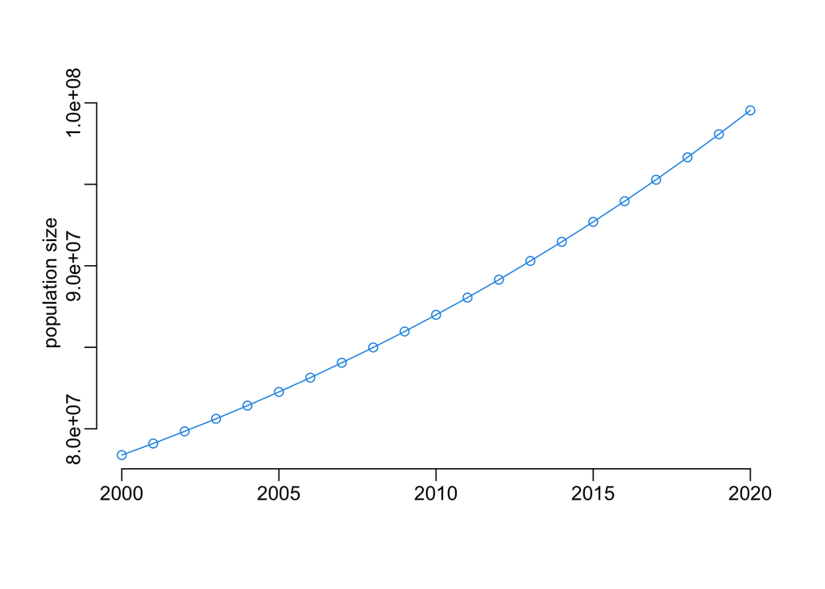

```r
pop_in_a_year <- function(x) {
  age_data %>%
    filter(year == x) %>%
    pull(n) %>%
    sum()
}

plot2 <- function(...) {
  plot(..., xlab = "", type = "o", col = 4)
}

years <- 2000:2020
pop_sizes <- map_dbl(years, pop_in_a_year)
plot2(years, pop_sizes, ylab = "population size")
```

Looks OK. Now, let’s see proportions of different age classes over the years, for the whole country again:

```r
tmp <- age_data %>%
  group_by(year, age) %>%
  summarise(n = sum(n)) %>%
  mutate(p = n / sum(n),
         p = cumsum(p)) %>%
  ungroup()
```

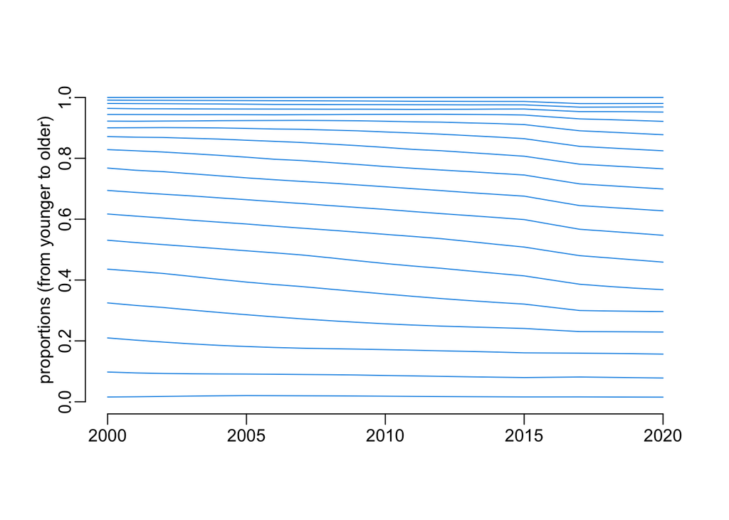

```r
with(tmp, plot(year, p, ylim = 0:1, type = "n", xlab = "",
               ylab = "proportions (from younger to older)"))

tmp %>%
  group_by(age) %>%
  group_walk(~ with(.x, lines(year, p, col = 4)))
```

Looks OK too, in the sense that the proportions of the age classes are not constant with time, and also that the population is getting older and older.